# project1

```python
import requests
from bs4 import BeautifulSoup
import pandas as pd
import numpy as np
from datetime import timedelta
import matplotlib.pyplot as plt
import seaborn as sns
```

```python
%matplotlib inline
```

```python
### Step 1 ####
# use request to get the url
r = requests.get('https://cmsc320.github.io/files/top-50-solar-flares.html')
```

```python
# extract the content
r_text = r.content
```

```python
# use BeautifulSoup to read and parse the data as html
text = BeautifulSoup(r_text,'html.parser')
```

```python
# view the content
print(text.prettify())
```

Not showing the output of 'print(text.prettify())' for saving space.

```python
# find the table, save as a variable
table = text.find('table')
```

```python
# read table
df_list = pd.read_html(r.text)
solar = df_list[0]
```

```python
# rename columns
solar.columns = ['rank', 'x_classification', 'date', 'region', 'start_time', 'maximum_time', 'end_time', 'movie']
```

```python
# preview the solar table
solar.head(10)
```

|  | rank | x_classification | date | region | start_time | maximum_time | end_time | movie |
| --- | --- | --- | --- | --- | --- | --- | --- | --- |
| 0 | 1 | X28+ | 2003/11/04 | 486 | 19:29 | 19:53 | 20:06 | MovieView archive |
| 1 | 2 | X20+ | 2001/04/02 | 9393 | 21:32 | 21:51 | 22:03 | MovieView archive |
| 2 | 3 | X17.2+ | 2003/10/28 | 486 | 09:51 | 11:10 | 11:24 | MovieView archive |
| 3 | 4 | X17+ | 2005/09/07 | 808 | 17:17 | 17:40 | 18:03 | MovieView archive |
| 4 | 5 | X14.4 | 2001/04/15 | 9415 | 13:19 | 13:50 | 13:55 | MovieView archive |
| 5 | 6 | X10 | 2003/10/29 | 486 | 20:37 | 20:49 | 21:01 | MovieView archive |
| 6 | 7 | X9.4 | 1997/11/06 | 8100 | 11:49 | 11:55 | 12:01 | MovieView archive |
| 7 | 8 | X9.3 | 2017/09/06 | 2673 | 11:53 | 12:02 | 12:10 | MovieView archive |
| 8 | 9 | X9 | 2006/12/05 | 930 | 10:18 | 10:35 | 10:45 | MovieView archive |
| 9 | 10 | X8.3 | 2003/11/02 | 486 | 17:03 | 17:25 | 17:39 | MovieView archive |

I use Beautiful Soup to scrape the table from the site and convert it into a dataframe through pandas. The columns are renamed to match with the table in SpaceWeatherLive site.

```python
#### Step 2 Tydy the top 50 solar flare data

# drop the last column
solar = solar.drop(columns = ['movie'])
```

```python
# combine date with time, update columns using assign
solar = solar.assign(
    start_time = pd.to_datetime(solar['date'].apply(str)+' '+solar['start_time']),
    maximum_time = pd.to_datetime(solar['date'].apply(str)+' '+solar['maximum_time']),
    end_time = pd.to_datetime(solar['date'].apply(str)+' '+solar['end_time'])
    )
```

```python
# Set regions coded as - as missing (Using an appropriate 'missing data' value).
solar['region']
```

```
0      486
1     9393
2      486
3      808
4     9415
5      486
6     8100
7     2673
8      930
9      486
10    2673
11     720
12    1263
13     930
14     808
```

[output cut: 36 more lines]

Following the instruction, I first drop the last column 'movie' since it will not be useful in the further analysis. Then I convert the date with time and convert it to timestamp for start time, maximum time and end time. Finally, by checking the 'region' column, there is no missing data for regions, therefore no observation of 'region' needs to be recoded.

```python
### Step 3 Scrape the NASA data ####
# scraping table and creating dataframe
r = requests.get('https://cmsc320.github.io/files/waves_type2.html')
root = BeautifulSoup(r.content,'html.parser')
```

```python
raw = root.find('pre').get_text()
```

```python
raw = raw.split('\n')
```

```python
raw_table = raw[12:-3]  # remove the top and the bottom, only keep the table content
```

```python
## Split strings to get each value and appedn the table
table = []
for item in raw_table:
    item = item.split()
    table.append(item)
```

```python
# create dataframe
nasa = pd.DataFrame(table)
```

```python
# keep all rows, remove unuseful columns
nasa = nasa.iloc[:, :15]
```

```python
# rename columns
nasa.columns = ['start_date','start_time','end_date','end_time','start_frequency', 'end_frequency', 'flare_location', 'flare_region', 'flare_imp',
                'cme_date', 'cme_time', 'cme_angle', 'cme_width', 'cme_speed', 'link']
```

```python
nasa.head(10)
```

|  | start_date | start_time | end_date | end_time | start_frequency | end_frequency | flare_location | flare_region | flare_imp | cme_date | cme_time | cme_angle | cme_width | cme_speed | link |
| --- | --- | --- | --- | --- | --- | --- | --- | --- | --- | --- | --- | --- | --- | --- | --- |
| 0 | 1997/04/01 | 14:00 | 04/01 | 14:15 | 8000 | 4000 | S25E16 | 8026 | M1.3 | 04/01 | 15:18 | 74 | 79 | 312 | PHTX |
| 1 | 1997/04/07 | 14:30 | 04/07 | 17:30 | 11000 | 1000 | S28E19 | 8027 | C6.8 | 04/07 | 14:27 | Halo | 360 | 878 | PHTX |
| 2 | 1997/05/12 | 05:15 | 05/14 | 16:00 | 12000 | 80 | N21W08 | 8038 | C1.3 | 05/12 | 05:30 | Halo | 360 | 464 | PHTX |
| 3 | 1997/05/21 | 20:20 | 05/21 | 22:00 | 5000 | 500 | N05W12 | 8040 | M1.3 | 05/21 | 21:00 | 263 | 165 | 296 | PHTX |
| 4 | 1997/09/23 | 21:53 | 09/23 | 22:16 | 6000 | 2000 | S29E25 | 8088 | C1.4 | 09/23 | 22:02 | 133 | 155 | 712 | PHTX |
| 5 | 1997/11/03 | 05:15 | 11/03 | 12:00 | 14000 | 250 | S20W13 | 8100 | C8.6 | 11/03 | 05:28 | 240 | 109 | 227 | PHTX |
| 6 | 1997/11/03 | 10:30 | 11/03 | 11:30 | 14000 | 5000 | S16W21 | 8100 | M4.2 | 11/03 | 11:11 | 233 | 122 | 352 | PHTX |
| 7 | 1997/11/04 | 06:00 | 11/05 | 04:30 | 14000 | 100 | S14W33 | 8100 | X2.1 | 11/04 | 06:10 | Halo | 360 | 785 | PHTX |
| 8 | 1997/11/06 | 12:20 | 11/07 | 08:30 | 14000 | 100 | S18W63 | 8100 | X9.4 | 11/06 | 12:10 | Halo | 360 | 1556 | PHTX |
| 9 | 1997/11/27 | 13:30 | 11/27 | 14:00 | 14000 | 7000 | N17E63 | 8113 | X2.6 | 11/27 | 13:56 | 98 | 91 | 441 | PHTX |

I first use BeautifulSoup to scrape the content from the site, and I split the text into a list of strings in which each string is a row of observations. Then I remove the top and the bottom strings to keep the table content only to have the 'raw_table'. For each item in the 'raw_table', I split the string to get each value and append the table with the value. Finally, I drop unuseful columns and rename the columns of the dataframe 'nasa'.

```python
### Step 4 ####
## (1) recode missing entries
## find all missing data

nasa['start_frequency'] = nasa['start_frequency'].replace('????', np. nan)
nasa['end_frequency'] = nasa['end_frequency'].replace('????', np. nan)
nasa['flare_region'] = nasa['flare_region'].replace('-----', np. nan)
nasa['flare_imp'] = nasa['flare_imp'].replace('----', np. nan)
nasa['cme_angle'] = nasa['cme_angle'].replace('----', np.nan)

### '----' in flare_imp, flare_region, cme_angle, cme_width, cem_speed are all NAs
nasa = nasa.replace('----', np.nan)

### 'BACK' in 'flare_region' and 'FILA' in 'flare_imp' and 'flare_region'
nasa['flare_region'] = nasa['flare_region'].replace('BACK', np. nan)
nasa['flare_region'] = nasa['flare_region'].replace('FILA', np. nan)
nasa['flare_imp'] = nasa['flare_imp'].replace('FILA', np. nan)
```

I recode the missing data in the manner as described in the data description. The nasa description does not cover all type of missing data, so I check the actual data and recode other missing values.

```python
## (2) cpa column
nasa['cme_angle']
## new column indicating 'Halo'
nasa = nasa.assign(halo_TF = [True if a == 'Halo' else False for a in nasa['cme_angle']])
## replace 'Halo' with NA
nasa['cme_angle'] = nasa['cme_angle'].replace('Halo', np. nan)
```

I replace 'Halo' with NA in the 'cme_angle' column. Also, I create a column indicating whether the flare is a halo flare by assigning True to 'Halo' and False to any other values in the 'cem_angle'.

```python
## (3) width column
# '>' means lower limit
## new column indicating lower bound
nasa = nasa.assign(lower_bound = [True if '>' in str(a) else False for a in nasa['cme_width']])
## check
nasa[['cme_width','lower_bound']].loc[nasa['lower_bound'] == True]

## remove '>' part of 'cme_width' column
nasa = nasa.assign(cme_width = [str(a)[1:] if '>' in str(a) else a for a in nasa['cme_width']])
```

I create a column 'lower_bound', in which I assign True for values contains '>' in the 'cme_width' column, and False for values do not contain '>'. And I remove '>' in the values in the 'cme_width' column.

```python
########## (4) combine date and time column for start, end and cme ############

### start time ###
## convert 'start_date' to timestamp
nasa['start_date'] = pd.to_datetime(nasa['start_date'])
## combine start date and time, conver to timestamp
nasa = nasa.assign(
    start_dt = pd.to_datetime(nasa['start_date'].apply(str) + ' ' + nasa['start_time'].apply(str))
)
```

I convert the 'start_date' to a timestamp. I convert the combined the start_date and start_time to a time stamp. The new column 'start_dt' is a timestamp for the start date and time.

```python
##### extract year of the date since there is no 'year' for 'end_date' and 'cme_date'
nasa['yr'] = pd.DatetimeIndex(nasa['start_date']).year
```

```python
## add year to 'end_date'
nasa = nasa.assign(
    end_date = nasa['yr'].apply(str) + '/' + nasa['end_date'].apply(str)
)
## convert 'end_date' with year to timestamp
nasa = nasa.assign(
    end_date = pd.to_datetime(nasa['end_date'])
)

### there is 24:00 in end_time that cannot be converted to timestamp
### for 'end_time' == 24:00, convert it to 00:00 and add one day to the 'end_date'
nasa['end_date'] = np.where(nasa.end_time == '24:00', nasa.end_date + timedelta(days = 1), nasa.end_date)
nasa['end_time'] = np.where(nasa.end_time == '24:00', '00:00', nasa.end_time)


## combine 'end_date' and 'end_time'
nasa = nasa.assign(
    end_dt = pd.to_datetime(nasa['end_date'].apply(str) + ' ' + nasa['end_time'].apply(str))
)
```

To get the timestamp of end date and time, I first need to extract the year information from the 'start_date' and add 'yr' to the 'end_date'. After I have the new version 'end_date', I convert it to a timestamp. Note that there is '24:00' in 'end_time' that cannot be converted to timestamp, so I recode the observation whose 'end_time' is '24:00'. I replace '24:00' with '00:00', meanwhile, I add one day to the corresponding 'end_date'. I combine the recoded 'end_date' and 'end_time' and convert it to a timestamp to create a new column 'end_dt'.

```python
####### there are missing values for 'cme_date' and 'cme_time' in the format of --/-- and --:--
### when combining date and time with year, the missing date and time will be autofilled with 01-01 and 00:00:00
### in case of --/-- and --:-- cannot be converted to timestamp, we first fill --/-- and --:-- with 01/01 and 00:00

## first create new column that recording missing for cme_date and cme_time

nasa['cme_missing_date'] = np.where(nasa.cme_date == '--/--', True, False)
nasa['cme_missing_time'] = np.where(nasa.cme_time == '--:--', True, False)

## fill '--/--' with '01/01'
nasa['cme_date'] = np.where(nasa.cme_date == '--/--', '01/01', nasa.cme_date)

## fill '--:--' with '00:00'
nasa['cme_time'] = np.where(nasa.cme_time == '--:--', '00:00', nasa.cme_time)
```

```python
## add year to cme_date
nasa = nasa.assign(
    cme_date = nasa['yr'].apply(str) + '/' + nasa['cme_date'].apply(str)
)
## combine date and time, convert to timestamp
nasa = nasa.assign(
    cme_dt = pd.to_datetime(nasa['cme_date'].apply(str) + ' ' + nasa['cme_time'].apply(str))
)
```

There are missing values for 'cme_date' and 'cme_time' in the format of '--/--' and '--:--'. When combining date and time with year, the missing date and time will be autofilled with '01-01' and '00:00:00'. Since '--/--' and '--:--' cannot be converted to timestamp, I first replace '--/--' and '--:--' with '01/01' and '00:00'. I also create columns indicating the missing of 'cme_date' and 'cme_time'. After recoding the 'cme_date' and 'cme_time', I create 'cme_dt' column by combining the 'cme_date' and 'cme_time', and converting it to timestamp.

```python
#### reorder columns ###
nasa = nasa[['start_dt', 'end_dt', 'start_frequency', 'end_frequency', 'flare_location', 'flare_region',
            'flare_imp', 'cme_dt', 'cme_angle', 'cme_width', 'cme_speed','link', 'halo_TF', 'lower_bound','start_date',
            'start_time', 'end_date', 'end_time', 'cme_date', 'cme_time','yr','cme_missing_date', 'cme_missing_time']]
```

I reorder the columns for clarity.

```python
### Q1 Replication
## The modern classification system for solar flares uses the letters A, B, C, M, or X
## The strength of an event within a class is noted by a numerical suffix ranging from 1 up to, but excluding, 10, which is also the factor for that event within the class.
## Hence, an X2 flare is twice the strength of an X1 flare, an X3 flare is three times as powerful as an X1

## rank the 'flare_imp' in the nasa dataset by letter and number, top 50 should match with the Top 50 solar flares in SpaceWeatherLive.com

nasa = nasa.assign(flare_letter = nasa['flare_imp'].str[0],
                  flare_number = pd.to_numeric(nasa['flare_imp'].str[1:]))
```

```python
top50 = nasa.sort_values(["flare_letter", "flare_number"], ascending = False).iloc[0:50,]
```

```python
top50.head(10)
```

|  | start_dt | end_dt | start_frequency | end_frequency | flare_location | flare_region | flare_imp | cme_dt | cme_angle | cme_width | ... | start_time | end_date | end_time | cme_date | cme_time | yr | cme_missing_date | cme_missing_time | flare_letter | flare_number |
| --- | --- | --- | --- | --- | --- | --- | --- | --- | --- | --- | --- | --- | --- | --- | --- | --- | --- | --- | --- | --- | --- |
| 240 | 2003-11-04 20:00:00 | 2003-11-05 00:00:00 | 10000 | 200 | S19W83 | 10486 | X28. | 2003-11-04 19:54:00 | NaN | 360 | ... | 20:00 | 2003-11-05 | 00:00 | 2003/11/04 | 19:54 | 2003 | False | False | X | 28.0 |
| 117 | 2001-04-02 22:05:00 | 2001-04-03 02:30:00 | 14000 | 250 | N19W72 | 9393 | X20. | 2001-04-02 22:06:00 | 261 | 244 | ... | 22:05 | 2001-04-03 | 02:30 | 2001/04/02 | 22:06 | 2001 | False | False | X | 20.0 |
| 233 | 2003-10-28 11:10:00 | 2003-10-30 00:00:00 | 14000 | 40 | S16E08 | 10486 | X17. | 2003-10-28 11:30:00 | NaN | 360 | ... | 11:10 | 2003-10-30 | 00:00 | 2003/10/28 | 11:30 | 2003 | False | False | X | 17.0 |
| 126 | 2001-04-15 14:05:00 | 2001-04-16 13:00:00 | 14000 | 40 | S20W85 | 9415 | X14. | 2001-04-15 14:06:00 | 245 | 167 | ... | 14:05 | 2001-04-16 | 13:00 | 2001/04/15 | 14:06 | 2001 | False | False | X | 14.0 |
| 234 | 2003-10-29 20:55:00 | 2003-10-30 00:00:00 | 11000 | 500 | S15W02 | 10486 | X10. | 2003-10-29 20:54:00 | NaN | 360 | ... | 20:55 | 2003-10-30 | 00:00 | 2003/10/29 | 20:54 | 2003 | False | False | X | 10.0 |
| 8 | 1997-11-06 12:20:00 | 1997-11-07 08:30:00 | 14000 | 100 | S18W63 | 8100 | X9.4 | 1997-11-06 12:10:00 | NaN | 360 | ... | 12:20 | 1997-11-07 | 08:30 | 1997/11/06 | 12:10 | 1997 | False | False | X | 9.4 |
| 514 | 2017-09-06 12:05:00 | 2017-09-07 08:00:00 | 16000 | 70 | S08W33 | 12673 | X9.3 | 2017-09-06 12:24:00 | NaN | 360 | ... | 12:05 | 2017-09-07 | 08:00 | 2017/09/06 | 12:24 | 2017 | False | False | X | 9.3 |
| 328 | 2006-12-05 10:50:00 | 2006-12-05 20:00:00 | 14000 | 250 | S07E68 | 10930 | X9.0 | 2006-01-01 00:00:00 | NaN | NaN | ... | 10:50 | 2006-12-05 | 20:00 | 2006/01/01 | 00:00 | 2006 | True | True | X | 9.0 |
| 237 | 2003-11-02 17:30:00 | 2003-11-03 01:00:00 | 12000 | 250 | S14W56 | 10486 | X8.3 | 2003-11-02 17:30:00 | NaN | 360 | ... | 17:30 | 2003-11-03 | 01:00 | 2003/11/02 | 17:30 | 2003 | False | False | X | 8.3 |
| 515 | 2017-09-10 16:02:00 | 2017-09-11 06:50:00 | 16000 | 150 | S09W92 | NaN | X8.3 | 2017-09-10 16:00:00 | NaN | 360 | ... | 16:02 | 2017-09-11 | 06:50 | 2017/09/10 | 16:00 | 2017 | False | False | X | 8.3 |

10 rows × 25 columns

To replicate the top 50 solar flares in SpaceWeather, I first split the flare importance ('flare_imp' in the nasa data) into letter and number. And I sort the nasa data by 'flare_letter' and then by 'flare_number' descendingly. And I subset the top 50 observations of the sorted nasa data as the replication of top 50 solar flares in SpaceWeatherLive. But there are some error in the nasa data of the flare importance, so we cannot get the exact replication of top 50 solar flares in SpaceWeatherLive from nasa data.

```python
### Q2 Integration
```

```python
solar = solar.assign(flare_letter = solar['x_classification'].str[0],
                     flare_number_approx = solar['x_classification'].str[1:],
                    start_date = pd.to_datetime(solar['date']))
```

```python
## 'flare_number_approx1' is created to deal with observation like 'X17+'. We want to get rid of the '+' in order to use the number in further calculations.
solar = solar.assign(flare_number_approx1 = pd.to_numeric(solar['flare_number_approx'].str.replace('+', '', regex = True)))
```

```python
## match on 'start_date'
match0 = pd.merge(solar, nasa,
                        how="left", on="start_date")
```

```python
match0.columns
```

```
Index(['rank', 'x_classification', 'date', 'region', 'start_time_x',
       'maximum_time', 'end_time_x', 'flare_letter_x', 'flare_number_approx',
       'start_date', 'flare_number_approx1', 'start_dt', 'end_dt',
       'start_frequency', 'end_frequency', 'flare_location', 'flare_region',
       'flare_imp', 'cme_dt', 'cme_angle', 'cme_width', 'cme_speed', 'link',
       'halo_TF', 'lower_bound', 'start_time_y', 'end_date', 'end_time_y',
       'cme_date', 'cme_time', 'yr', 'cme_missing_date', 'cme_missing_time',
       'flare_letter_y', 'flare_number'],
      dtype='object')
```

```python
## dealing with duplicate matches
match0 = match0.assign(diff = abs(match0['flare_number'] - match0['flare_number_approx1']))
## mutate difference variable
## for duplicates in 'rank', keep the one with lower difference
match0 = match0.sort_values(by='diff', ascending=True).drop_duplicates('rank', keep='first').sort_values(by='rank', ascending=True)
```

```python
### if 'start_dt' is not NA, then the observation in SWL has a match in nasa
match0['match'] = match0['start_dt'].notna()
```

```python
best_match = match0[['rank', 'x_classification', 'date', 'region', 'start_time_x',
       'maximum_time', 'end_time_x', 'match',
       'start_dt', 'end_dt',
       'start_frequency', 'end_frequency', 'flare_location', 'flare_region',
       'flare_imp', 'cme_dt', 'cme_angle', 'cme_width', 'cme_speed', 'link',
       'halo_TF', 'lower_bound']]
```

```python
best_match.head(10)
```

|  | rank | x_classification | date | region | start_time_x | maximum_time | end_time_x | match | start_dt | end_dt | ... | flare_location | flare_region | flare_imp | cme_dt | cme_angle | cme_width | cme_speed | link | halo_TF | lower_bound |
| --- | --- | --- | --- | --- | --- | --- | --- | --- | --- | --- | --- | --- | --- | --- | --- | --- | --- | --- | --- | --- | --- |
| 0 | 1 | X28+ | 2003/11/04 | 486 | 2003-11-04 19:29:00 | 2003-11-04 19:53:00 | 2003-11-04 20:06:00 | True | 2003-11-04 20:00:00 | 2003-11-05 00:00:00 | ... | S19W83 | 10486 | X28. | 2003-11-04 19:54:00 | NaN | 360 | 2657 | PHTX | True | False |
| 2 | 2 | X20+ | 2001/04/02 | 9393 | 2001-04-02 21:32:00 | 2001-04-02 21:51:00 | 2001-04-02 22:03:00 | True | 2001-04-02 22:05:00 | 2001-04-03 02:30:00 | ... | N19W72 | 9393 | X20. | 2001-04-02 22:06:00 | 261 | 244 | 2505 | PHTX | False | False |
| 3 | 3 | X17.2+ | 2003/10/28 | 486 | 2003-10-28 09:51:00 | 2003-10-28 11:10:00 | 2003-10-28 11:24:00 | True | 2003-10-28 11:10:00 | 2003-10-30 00:00:00 | ... | S16E08 | 10486 | X17. | 2003-10-28 11:30:00 | NaN | 360 | 2459 | PHTX | True | False |
| 4 | 4 | X17+ | 2005/09/07 | 808 | 2005-09-07 17:17:00 | 2005-09-07 17:40:00 | 2005-09-07 18:03:00 | True | 2005-09-07 18:05:00 | 2005-09-08 00:00:00 | ... | S11E77 | 10808 | X1.7 | 2005-01-01 00:00:00 | NaN | NaN | NaN | PHTX | False | False |
| 5 | 5 | X14.4 | 2001/04/15 | 9415 | 2001-04-15 13:19:00 | 2001-04-15 13:50:00 | 2001-04-15 13:55:00 | True | 2001-04-15 14:05:00 | 2001-04-16 13:00:00 | ... | S20W85 | 9415 | X14. | 2001-04-15 14:06:00 | 245 | 167 | 1199 | PHTX | False | False |
| 6 | 6 | X10 | 2003/10/29 | 486 | 2003-10-29 20:37:00 | 2003-10-29 20:49:00 | 2003-10-29 21:01:00 | True | 2003-10-29 20:55:00 | 2003-10-30 00:00:00 | ... | S15W02 | 10486 | X10. | 2003-10-29 20:54:00 | NaN | 360 | 2029 | PHTX | True | False |
| 7 | 7 | X9.4 | 1997/11/06 | 8100 | 1997-11-06 11:49:00 | 1997-11-06 11:55:00 | 1997-11-06 12:01:00 | True | 1997-11-06 12:20:00 | 1997-11-07 08:30:00 | ... | S18W63 | 8100 | X9.4 | 1997-11-06 12:10:00 | NaN | 360 | 1556 | PHTX | True | False |
| 8 | 8 | X9.3 | 2017/09/06 | 2673 | 2017-09-06 11:53:00 | 2017-09-06 12:02:00 | 2017-09-06 12:10:00 | True | 2017-09-06 12:05:00 | 2017-09-07 08:00:00 | ... | S08W33 | 12673 | X9.3 | 2017-09-06 12:24:00 | NaN | 360 | 1571 | PHTX | True | False |
| 9 | 9 | X9 | 2006/12/05 | 930 | 2006-12-05 10:18:00 | 2006-12-05 10:35:00 | 2006-12-05 10:45:00 | True | 2006-12-05 10:50:00 | 2006-12-05 20:00:00 | ... | S07E68 | 10930 | X9.0 | 2006-01-01 00:00:00 | NaN | NaN | NaN | PHTX | False | False |
| 11 | 10 | X8.3 | 2003/11/02 | 486 | 2003-11-02 17:03:00 | 2003-11-02 17:25:00 | 2003-11-02 17:39:00 | True | 2003-11-02 17:30:00 | 2003-11-03 01:00:00 | ... | S14W56 | 10486 | X8.3 | 2003-11-02 17:30:00 | NaN | 360 | 2598 | PHTX | True | False |

10 rows × 22 columns

I select 'start_date' for matching. I use 'start_date' as the matching indicator because it has no missing value. Also, any more specific time record like hour or minute in the 'start_time', 'end_time' cannot be matched exactly between two datasets.

There are some duplicates matches, which have the same 'start_date' and 'flare_letter'. For these duplicates, I keep the one with 'flare_number' closest to the number in 'x_classification'. To identify the closest one, I first calculate a difference between the 'flare_number' (nasa) and 'flare_number_approx1' (number of x_classification in SWL). And then I sort the difference ascendingly to keep the first observation for each duplicate sets.

```python
### Q3 Analysis
## b) Do strong flares cluster in time?
cluster = top50.assign(month_name = top50['start_date'].dt.strftime('%b'),
                       month_num = pd.DatetimeIndex(top50['start_date']).month).sort_values(by = 'month_num', ascending = True)
```

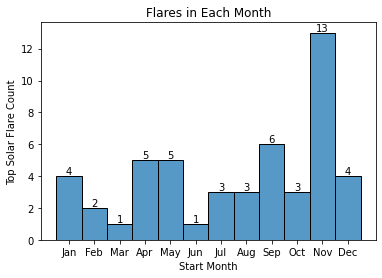

```python
distr = sns.histplot(cluster['month_name'], kde = False, bins = 12)
distr.set(xlabel ="Start Month", ylabel = "Top Solar Flare Count", title ='Flares in Each Month')
for p in distr.patches:
             distr.annotate("%.0f" % p.get_height(), (p.get_x() + p.get_width() / 2., p.get_height()),
                 ha='center', va='center', fontsize=10, color='black', xytext=(0, 5),
                 textcoords='offset points')
plt.show()
```

I plot the histogram of count of Top50 solar flares in each month to present the clustering of strong flares in time. The data used to plot histogram is from NASA. I ranked the flares by its importance and selected the top 50 flares.  
The months are on the x axis and the count of Top50 solar flare is on the y axis. The number on the top of the bar and also the height of the bar visually show how the strong solar flares cluster in time. As shown in the figure, November has the most strong solar flares. The number of strong solar flares first decrease from Janurary to March, and then increase a little in April and May. In general, the number of strong solar flares fluctuates from Janurary to October and reaches a peak in November, and finally drops in Decemeber. Therefore, the histogram indicates that strong flares cluster in November.